# Cartografía básica

Julián A. Velasco

9/25/2020

Aquí empezaremos con algunos ejercicios para trabajar con objetos espaciales y hacer algunos mapas básicos. Vamos a generar unos datos aleatorios de coordenadas geográficas y de precipitación.

```r
name <- LETTERS[1:10]
longitud <- c(-116.7, -120.4, -116.7, -113.5, -115.5,
-120.8, -119.5, -113.7, -113.7, -110.7)
latitud <- c(45.3, 42.6, 38.9, 42.1, 35.7, 38.9,
36.2, 39, 41.6, 36.9)
estaciones <- cbind(longitud, latitud)

# Simular datos de precipitación
set.seed(0)
# función runif: sirve para generar valores aleatorios siguiendo una distribución uniforme
precip <- (runif(length(latitud))*10)^3
```

Ahora vamos a gráficar estos datos y el tamaño de los puntos será proporcional a la cantidad de precipitación.

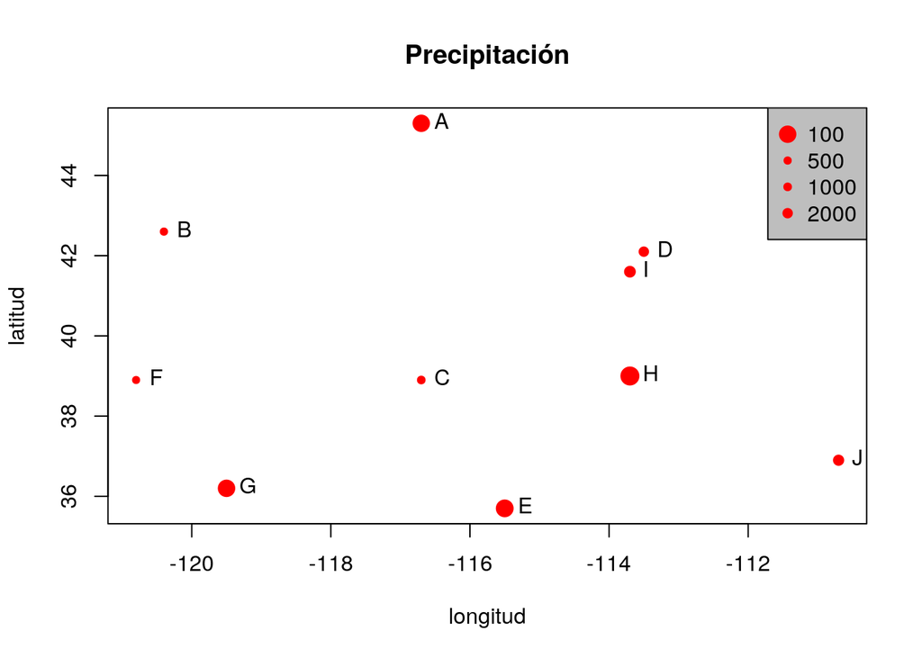

```r
psize <- 1 + precip/500
plot(estaciones, cex=psize, pch=20, col='red', main='Precipitación')

# adicionarle los nombres a la gráfica
text(estaciones, name, pos=4)

# adicionar una leyenda
breaks <- c(100, 500, 1000, 2000)
legend("topright", legend=breaks, pch=20, pt.cex=psize, col='red', bg='gray')
```

Puntos espaciales:

Vamos a generar vectores con datos de longitud y latitud, y luego los combinamos.

```r
longitude <- c(-116.7, -120.4, -116.7, -113.5, -115.5, -120.8, -119.5, -113.7, -113.7, -110.7)
latitude <- c(45.3, 42.6, 38.9, 42.1, 35.7, 38.9, 36.2, 39, 41.6, 36.9)
lonlat <- cbind(longitude, latitude)
```

Vamos a usar el paquete “sp”. D Debemos instalarlo usando la función install.packages(“sp”) y luego cargarlo con library(sp)

```r
# install.packages("sp")
library(sp)
pts <- SpatialPoints(lonlat)
```

¿Qué clase de objeto es?

```r
class(pts)
```

```
## [1] "SpatialPoints"
## attr(,"package")
## [1] "sp"
```

Exploramos que tiene

```r
showDefault(pts)
```

```
## An object of class "SpatialPoints"
## Slot "coords":
##       longitude latitude
##  [1,]    -116.7     45.3
##  [2,]    -120.4     42.6
##  [3,]    -116.7     38.9
##  [4,]    -113.5     42.1
##  [5,]    -115.5     35.7
##  [6,]    -120.8     38.9
##  [7,]    -119.5     36.2
##  [8,]    -113.7     39.0
##  [9,]    -113.7     41.6
## [10,]    -110.7     36.9
##
## Slot "bbox":
##              min    max
## longitude -120.8 -110.7
## latitude    35.7   45.3
##
## Slot "proj4string":
## CRS arguments: NA
```

El sistema de coordenadas de referencia de nuestro objeto espacial no está definido. Vamos a definirlo con la ayuda de la función CRS

```r
crdref <- CRS('+proj=longlat +datum=WGS84')
pts <- SpatialPoints(lonlat, proj4string=crdref)
```

Cargamos el paquete raster

```r
library(raster)
pts
```

```
## class       : SpatialPoints
## features    : 10
## extent      : -120.8, -110.7, 35.7, 45.3  (xmin, xmax, ymin, ymax)
## crs         : +proj=longlat +datum=WGS84 +ellps=WGS84 +towgs84=0,0,0
```

Vamos a generar (inventar) unos datos de precipitación asociados a esas coordenadas. Estos datos NO son reales, es solo para mostrar como podemos visualizarlos como objetos espaciales.

```r
df <- data.frame(ID=1:nrow(lonlat), precip=(latitude-30)^3)
```

Combinamos los datos espaciales y los datos de precipitación

```r
ptsdf <- SpatialPointsDataFrame(pts, data=df)
ptsdf
```

```
## class       : SpatialPointsDataFrame
## features    : 10
## extent      : -120.8, -110.7, 35.7, 45.3  (xmin, xmax, ymin, ymax)
## crs         : +proj=longlat +datum=WGS84 +ellps=WGS84 +towgs84=0,0,0
## variables   : 2
## names       : ID,   precip
## min values  :  1,  185.193
## max values  : 10, 3581.577
```

Vemos que tiene ese objeto espacial

```r
str(ptsdf)
```

```
## Formal class 'SpatialPointsDataFrame' [package "sp"] with 5 slots
##   ..@ data       :'data.frame':  10 obs. of  2 variables:
##   .. ..$ ID    : int [1:10] 1 2 3 4 5 6 7 8 9 10
##   .. ..$ precip: num [1:10] 3582 2000 705 1772 185 ...
##   ..@ coords.nrs : num(0)
##   ..@ coords     : num [1:10, 1:2] -117 -120 -117 -114 -116 ...
##   .. ..- attr(*, "dimnames")=List of 2
##   .. .. ..$ : NULL
##   .. .. ..$ : chr [1:2] "longitude" "latitude"
##   ..@ bbox       : num [1:2, 1:2] -120.8 35.7 -110.7 45.3
##   .. ..- attr(*, "dimnames")=List of 2
##   .. .. ..$ : chr [1:2] "longitude" "latitude"
##   .. .. ..$ : chr [1:2] "min" "max"
##   ..@ proj4string:Formal class 'CRS' [package "sp"] with 1 slot
##   .. .. ..@ projargs: chr "+proj=longlat +datum=WGS84 +ellps=WGS84 +towgs84=0,0,0"
```

También podemos verlos así:

```r
showDefault(ptsdf)
```

```
## An object of class "SpatialPointsDataFrame"
## Slot "data":
##    ID   precip
## 1   1 3581.577
## 2   2 2000.376
## 3   3  704.969
## 4   4 1771.561
## 5   5  185.193
## 6   6  704.969
## 7   7  238.328
## 8   8  729.000
## 9   9 1560.896
## 10 10  328.509
##
## Slot "coords.nrs":
## numeric(0)
##
## Slot "coords":
##       longitude latitude
##  [1,]    -116.7     45.3
##  [2,]    -120.4     42.6
##  [3,]    -116.7     38.9
##  [4,]    -113.5     42.1
##  [5,]    -115.5     35.7
##  [6,]    -120.8     38.9
##  [7,]    -119.5     36.2
##  [8,]    -113.7     39.0
##  [9,]    -113.7     41.6
## [10,]    -110.7     36.9
##
## Slot "bbox":
##              min    max
## longitude -120.8 -110.7
## latitude    35.7   45.3
##
## Slot "proj4string":
## CRS arguments:
##  +proj=longlat +datum=WGS84 +ellps=WGS84 +towgs84=0,0,0
```

Líneas y polígonos espaciales. Hacer puntos espaciales es bastante fácil. Hacer líneas y polígonos es un poco más complicado pero vamos a usar las funciones SpatialLines y SpatialPolygons para esto.

```r
lon <- c(-116.8, -114.2, -112.9, -111.9, -114.2, -115.4, -117.7)
lat <- c(41.3, 42.9, 42.4, 39.8, 37.6, 38.3, 37.6)
lonlat <- cbind(lon, lat)
lns <- spLines(lonlat, crs=crdref)
lns
```

```
## class       : SpatialLines
## features    : 1
## extent      : -117.7, -111.9, 37.6, 42.9  (xmin, xmax, ymin, ymax)
## crs         : +proj=longlat +datum=WGS84 +ellps=WGS84 +towgs84=0,0,0
```

Graficamos nuestro objeto de líneas

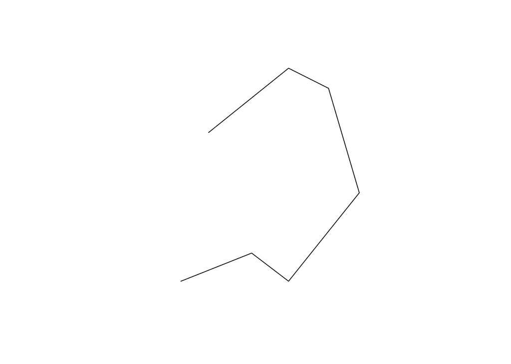

```r
plot(lns)
```

Creamos un shapefile (polígono) con los puntos

```r
pols <- spPolygons(lonlat, crs=crdref)
pols
```

```
## class       : SpatialPolygons
## features    : 1
## extent      : -117.7, -111.9, 37.6, 42.9  (xmin, xmax, ymin, ymax)
## crs         : +proj=longlat +datum=WGS84 +ellps=WGS84 +towgs84=0,0,0
```

Graficamos el polígono

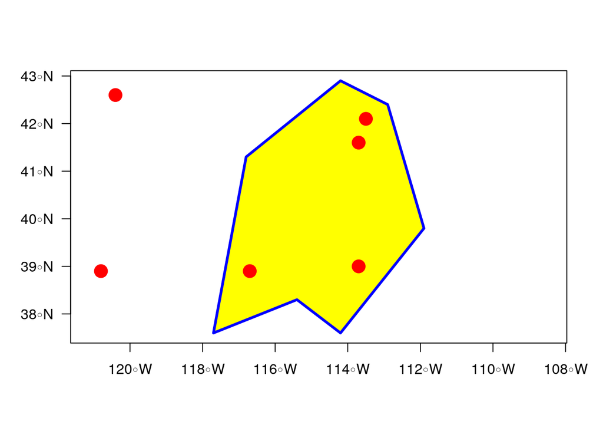

```r
plot(pols, axes=TRUE, las=1)
plot(pols, border='blue', col='yellow', lwd=3, add=TRUE)
points(pts, col='red', pch=20, cex=3)
```

Ahora vamos a manipular algunos archivos tipo raster

El paquete sp permite trabajar con archivos de clase SpatialGridDataFrame y SpatialPixelsDataFrame. Estos archivos son archivos que usamos muy a menudo en operaciones espaciales y SIG. De aquí en adelante nos vamos a empezar a usar el paqute raster para trabajar con archivo tipo raster (celdas). Con este paquete podemos hacer operaciones matemáticas con rasters y un sinnúmero de otros procesos que se usan en programas dedicadas a SIG (e.g., ArcGIS, QGIS, etc.).

¿Qué es un capa de tipo raster? Un RasterLayer es un objeto de R que contiene datos de una sola variables. Como vimos en la clase este objeto debe tener información del número de celdas, hileras (rows) y columnas (columns), la extensión geográfica o espacial (x, y - min-, -max-) y lo más importante en SIG: el sistema de coordenadas de referencia.

```r
library(raster)
r <- raster(ncol=10, nrow=10, xmx=-80, xmn=-150, ymn=20, ymx=60)
r
```

```
## class      : RasterLayer
## dimensions : 10, 10, 100  (nrow, ncol, ncell)
## resolution : 7, 4  (x, y)
## extent     : -150, -80, 20, 60  (xmin, xmax, ymin, ymax)
## crs        : +proj=longlat +datum=WGS84 +ellps=WGS84 +towgs84=0,0,0
```

```r
values(r) <- runif(ncell(r))
r
```

```
## class      : RasterLayer
## dimensions : 10, 10, 100  (nrow, ncol, ncell)
## resolution : 7, 4  (x, y)
## extent     : -150, -80, 20, 60  (xmin, xmax, ymin, ymax)
## crs        : +proj=longlat +datum=WGS84 +ellps=WGS84 +towgs84=0,0,0
## source     : memory
## names      : layer
## values     : 0.01339033, 0.9926841  (min, max)
```

Ahora podemos gráficar y ver como sale nuestro raster

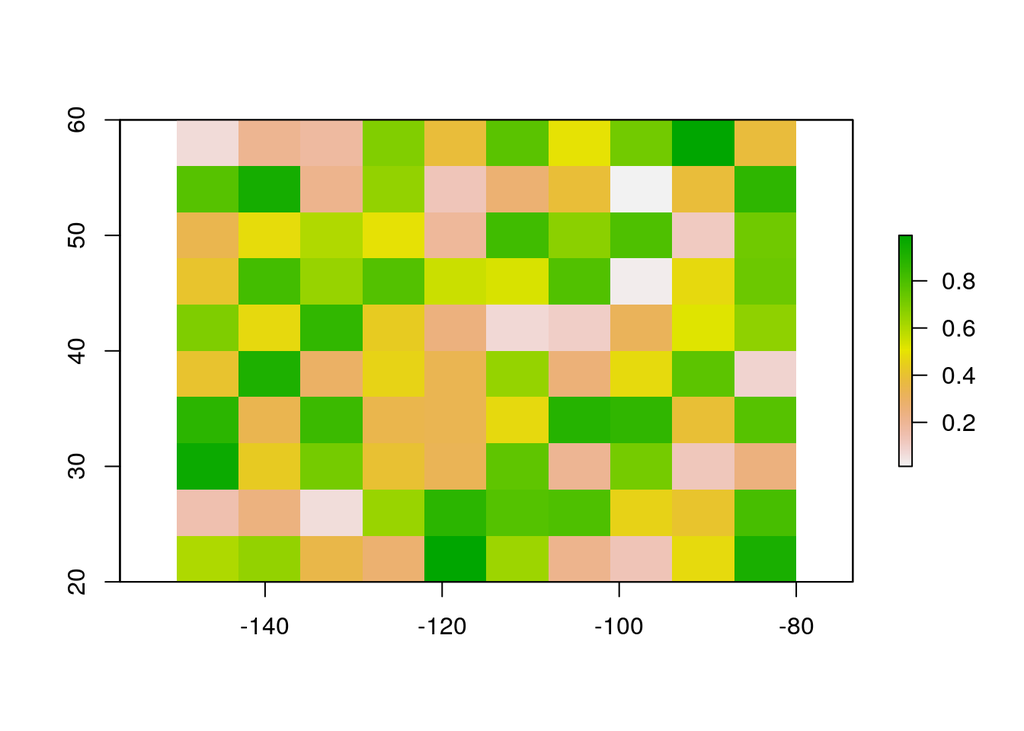

```r
plot(r)
```

Ahora vamos a subir unas capas climáticas que tenemos guardadas en nuestro computador.

```r
capas <- list.files(path="/home/julian/Documents/Taller_R/Cartografia/Capas_clima/", pattern=".tif", full.names = T)
capas <- stack(capas)
capas
```

```
## class      : RasterStack
## dimensions : 180, 360, 64800, 19  (nrow, ncol, ncell, nlayers)
## resolution : 1, 1  (x, y)
## extent     : -180, 180, -90, 90  (xmin, xmax, ymin, ymax)
## crs        : NA
## names      :      bio_01,      bio_02,      bio_03,      bio_04,      bio_05,      bio_06,      bio_07,      bio_08,      bio_09,      bio_10,      bio_11,      bio_12,      bio_13,      bio_14,      bio_15, ...
## min values : -234.128322,    9.500000,    9.396564,   68.000000,  -55.126503, -525.923628,   53.489130, -237.702800, -432.567114,  -91.281594, -471.184995,    0.000000,    0.000000,    0.000000,    0.000000, ...
## max values :    313.0625,    195.2251,     95.0000,  22549.9589,    484.3726,    258.0000,    722.3212,    369.2097,    355.0000,    375.4345,    288.8571,   6995.0284,   1482.7247,    345.1818,    215.9236, ...
```

Ahora vamos a graficar una sola capa climática (bio1)

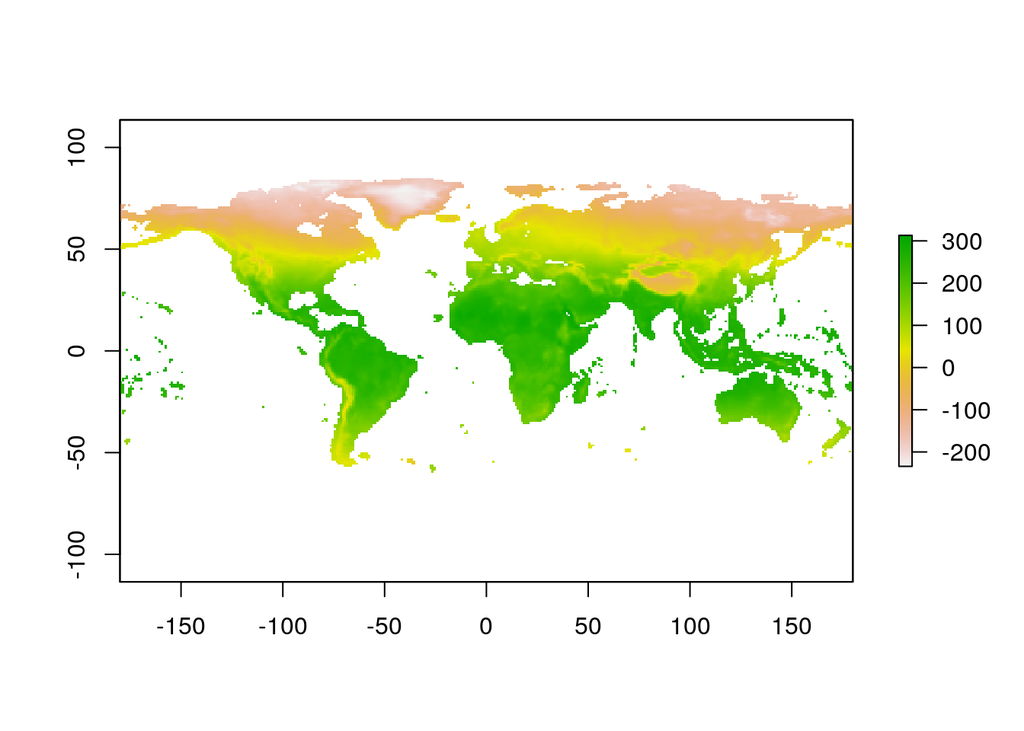

```r
plot(capas[[1]])
```

Vamos a jugar un poco con shapefiles y rasters

```r
library(rgdal)
ame1 <- readOGR(dsn="/home/julian/Documents/Taller_R/Cartografia/Shapefile", layer="cont_america")
ame2 <- readOGR("/home/julian/Documents/Taller_R/Cartografia/Shapefile/cont_america.shp")
```

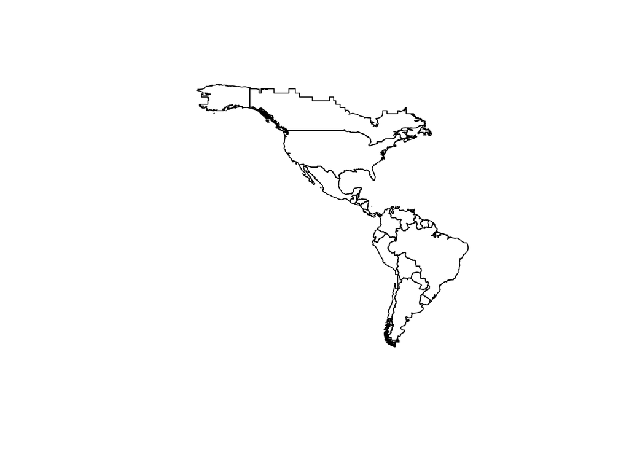

```r
plot(ame1)
plot(ame2)
```

Vamos a indexar un país y luego cortar las capas climáticas para ese país

```r
head(ame1)
```

```
##                   PAÍS
## 0 Aruba (Paises Bajos)
## 1            Argentina
## 2               Belice
## 3              Bolivia
## 4               Brasil
## 5               Canadá
```

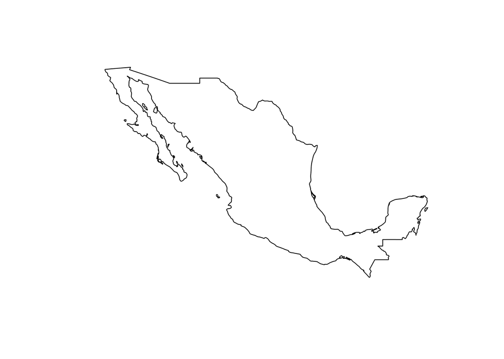

```r
mx <- subset(ame1, PAÍS=="México")
plot(mx)
```

Cortamos las capas usando la función mask. También podemos usar la función crop

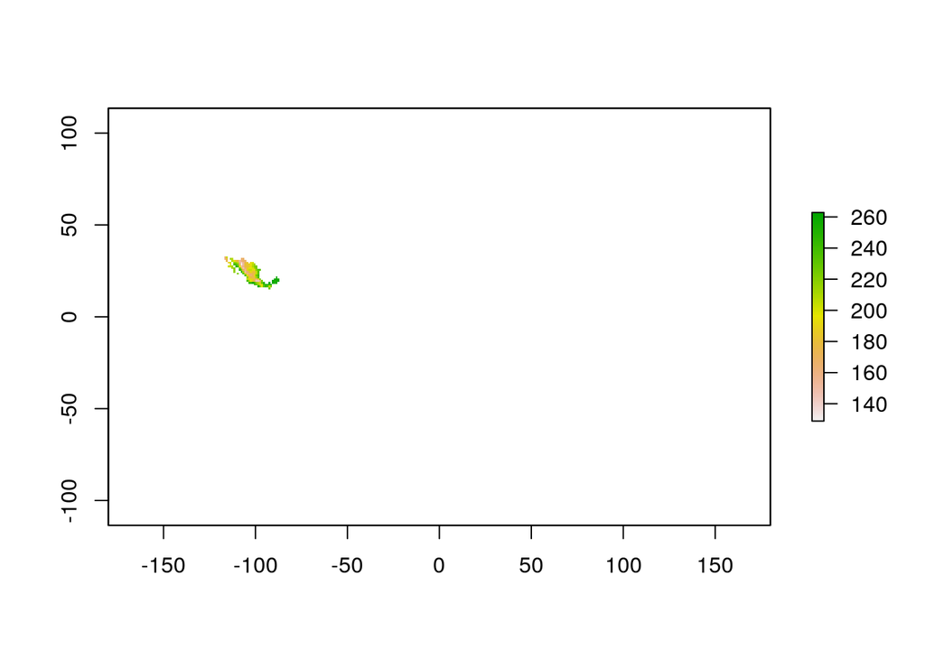

```r
# Usando mask
mx.clima <- raster::mask(capas, mx)
plot(mx.clima[[1]])
```

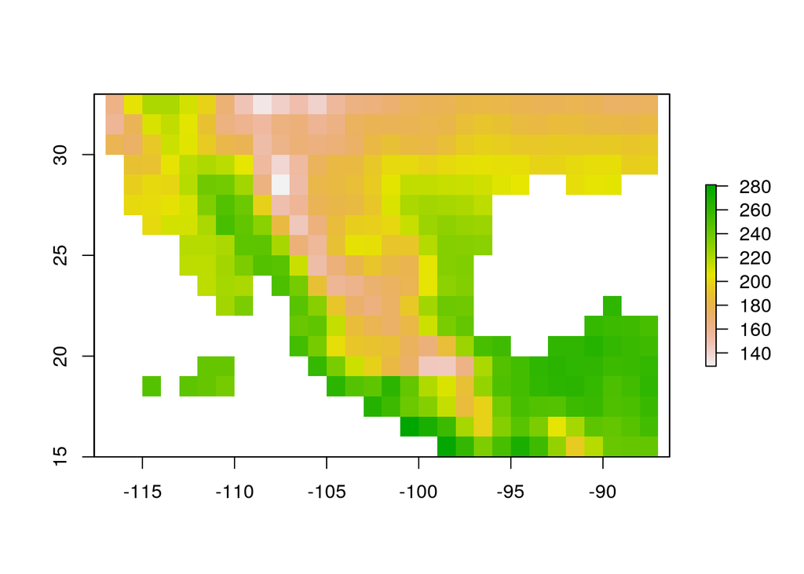

```r
# Usando crop
mx.clima.v2 <- raster::crop(capas, mx)
plot(mx.clima.v2[[1]])
```

Lo ideal es primero crop y luego mask

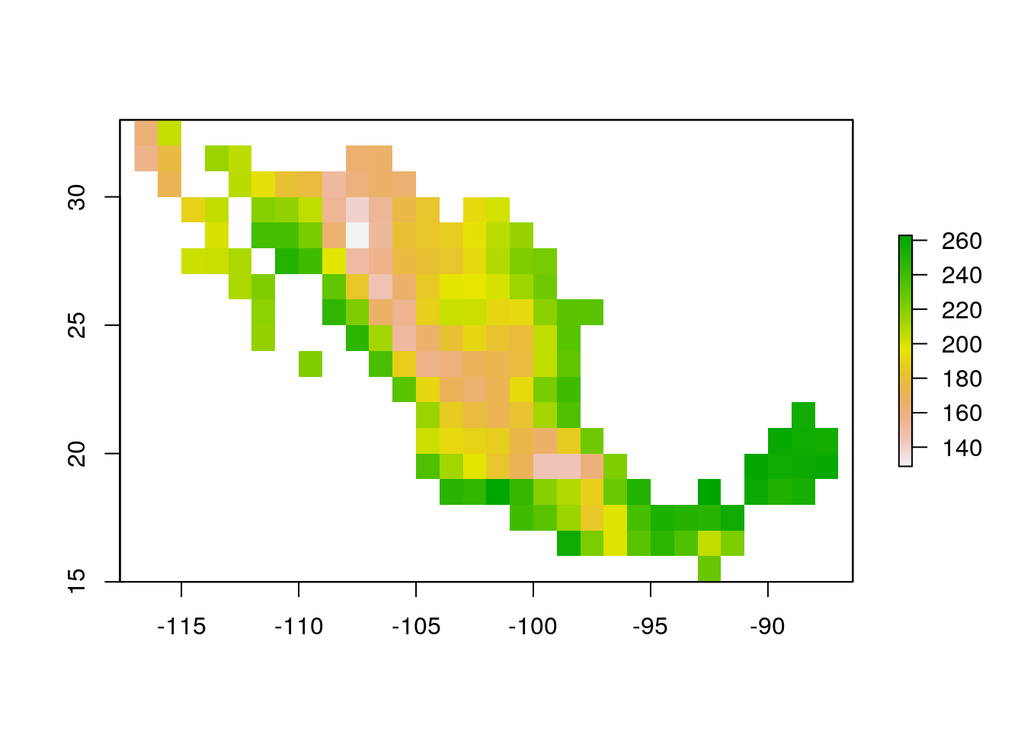

```r
mx.clima.v3 <- crop(capas, mx)
mx.clima.v3 <- mask(mx.clima.v3, mx)
plot(mx.clima.v3[[1]])
```

Agregarle el mapa de México como contorno

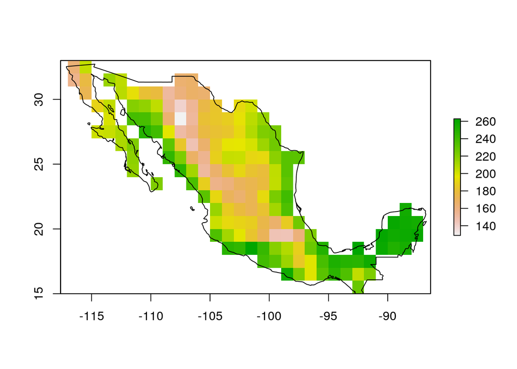

```r
plot(mx.clima.v3[[1]])
plot(mx, add=T)
```

Eso es todo por ahora.

Adaptado de http://www.rspatial.org/intr/index.html (R. Hijmans, 2016)